# Individual Differences in Cognitive Flexibility

A Latent-Change Structural Equation Modeling Approach

Mareike J. Hülsemann, Christoph Löffler, & Anna-Lena Schubert

26 September 2025

# DESCRIPTIVE STATISTICS

## TASK PERFORMANCE

For flexibility tasks, all participants performing below 70 % accuracy were removed from the time-frequency analysis. This is equivalent to remove all participants performing 2 SD below the mean performance. No such cutoff was defined for BIS or memory tasks. The BIS is quality checked during manual scoring. For the memory tasks, it might be, that participants perform at chance level, especially for higher memory loads, because they are at the top of their working memory capacity. These data should not be eliminated. However, general outlier analyses are conducted and univariate outliers are removed (z-standardized values > $\pm$ 3).

## DISTRIBUTION

We check whether data is normally distributed.

Distribution of variables in raw data

|  | vars | n | mean | sd | median | trimmed | mad | min | max | range | skew | kurtosis | se |
| --- | --- | --- | --- | --- | --- | --- | --- | --- | --- | --- | --- | --- | --- |
| id | 1 | 148 | 74.500 | 42.868 | 74.500 | 74.500 | 54.856 | 1.000 | 148.000 | 147.000 | 0.000 | -1.224 | 3.524 |
| age | 2 | 148 | 31.520 | 13.906 | 24.000 | 29.867 | 5.930 | 18.000 | 60.000 | 42.000 | 0.945 | -0.734 | 1.143 |
| WMC_MU | 3 | 139 | 0.630 | 0.202 | 0.662 | 0.640 | 0.219 | 0.143 | 0.973 | 0.830 | -0.397 | -0.764 | 0.017 |
| WMC_Binding | 4 | 133 | 0.861 | 0.110 | 0.900 | 0.877 | 0.085 | 0.520 | 1.000 | 0.480 | -1.190 | 0.801 | 0.010 |
| WMC_OpSp | 5 | 135 | 0.777 | 0.130 | 0.806 | 0.787 | 0.108 | 0.426 | 1.000 | 0.574 | -0.736 | 0.117 | 0.011 |
| WMC_SenSp | 6 | 139 | 0.826 | 0.149 | 0.872 | 0.848 | 0.105 | 0.120 | 1.000 | 0.880 | -2.130 | 6.396 | 0.013 |
| BIS_PC | 7 | 140 | 101.609 | 7.122 | 102.000 | 101.604 | 7.287 | 85.000 | 118.670 | 33.670 | -0.018 | -0.242 | 0.602 |
| BIS_M | 8 | 140 | 98.588 | 7.161 | 98.330 | 98.485 | 6.924 | 83.670 | 116.000 | 32.330 | 0.124 | -0.500 | 0.605 |
| BIS_PS | 9 | 140 | 101.141 | 7.149 | 101.500 | 101.188 | 7.161 | 82.000 | 119.000 | 37.000 | -0.105 | -0.154 | 0.604 |
| BIS_C | 10 | 140 | 98.154 | 6.970 | 98.500 | 98.178 | 6.672 | 80.330 | 114.000 | 33.670 | -0.095 | -0.309 | 0.589 |
| V_Mean | 11 | 140 | 104.863 | 5.886 | 105.800 | 105.202 | 5.930 | 88.200 | 121.600 | 33.400 | -0.473 | 0.310 | 0.497 |
| N_Mean | 12 | 140 | 98.690 | 7.262 | 98.800 | 98.679 | 7.116 | 81.400 | 121.000 | 39.600 | 0.051 | -0.238 | 0.614 |
| F_Mean | 13 | 140 | 97.107 | 6.758 | 96.700 | 97.379 | 6.079 | 77.800 | 112.600 | 34.800 | -0.341 | 0.129 | 0.571 |
| g_Mean | 14 | 140 | 100.220 | 5.308 | 100.600 | 100.419 | 5.389 | 84.400 | 117.130 | 32.730 | -0.254 | 0.341 | 0.449 |
| G_total | 15 | 140 | 97.086 | 10.613 | 98.000 | 97.527 | 10.378 | 70.000 | 130.000 | 60.000 | -0.279 | 0.191 | 0.897 |
| cue_Theta_oddeven_switch_all | 16 | 142 | 0.786 | 0.950 | 0.851 | 0.793 | 0.834 | -1.647 | 3.180 | 4.827 | -0.045 | -0.247 | 0.080 |
| cue_Theta_oddeven_repeat_all | 17 | 142 | 0.588 | 0.926 | 0.627 | 0.610 | 0.777 | -2.083 | 3.128 | 5.211 | -0.168 | 0.358 | 0.078 |
| cue_Theta_oddeven_switch_odd | 18 | 142 | 0.720 | 1.055 | 0.702 | 0.744 | 0.964 | -2.366 | 3.076 | 5.442 | -0.254 | 0.190 | 0.089 |
| cue_Theta_oddeven_switch_even | 19 | 142 | 0.810 | 0.985 | 0.841 | 0.821 | 1.037 | -1.916 | 3.276 | 5.192 | -0.112 | -0.142 | 0.083 |
| cue_Theta_oddeven_repeat_odd | 20 | 142 | 0.535 | 1.040 | 0.609 | 0.555 | 1.036 | -2.668 | 3.219 | 5.887 | -0.155 | 0.104 | 0.087 |
| cue_Theta_oddeven_repeat_even | 21 | 142 | 0.591 | 0.973 | 0.645 | 0.612 | 0.771 | -1.823 | 3.011 | 4.834 | -0.132 | -0.079 | 0.082 |
| cue_Theta_oddeven_diff_all | 22 | 142 | 0.198 | 0.530 | 0.213 | 0.212 | 0.472 | -1.484 | 1.549 | 3.033 | -0.334 | 0.703 | 0.044 |
| cue_Theta_oddeven_diff_odd | 23 | 142 | 0.185 | 0.717 | 0.184 | 0.203 | 0.657 | -1.649 | 1.807 | 3.457 | -0.232 | -0.248 | 0.060 |
| cue_Theta_oddeven_diff_even | 24 | 142 | 0.218 | 0.742 | 0.243 | 0.231 | 0.640 | -2.804 | 1.999 | 4.803 | -0.441 | 1.410 | 0.062 |
| cue_Theta_globallocal_switch_all | 25 | 144 | -0.042 | 0.762 | -0.002 | -0.001 | 0.631 | -3.438 | 1.625 | 5.062 | -0.804 | 2.019 | 0.064 |
| cue_Theta_globallocal_repeat_all | 26 | 144 | -0.270 | 0.756 | -0.134 | -0.229 | 0.631 | -3.908 | 1.159 | 5.067 | -0.991 | 2.606 | 0.063 |
| cue_Theta_globallocal_switch_odd | 27 | 144 | -0.062 | 0.862 | -0.078 | -0.023 | 0.782 | -4.082 | 1.999 | 6.082 | -0.839 | 2.797 | 0.072 |
| cue_Theta_globallocal_switch_even | 28 | 144 | -0.069 | 0.793 | -0.006 | -0.029 | 0.727 | -2.898 | 1.554 | 4.452 | -0.595 | 0.598 | 0.066 |
| cue_Theta_globallocal_repeat_odd | 29 | 144 | -0.297 | 0.774 | -0.307 | -0.263 | 0.738 | -3.971 | 1.302 | 5.273 | -0.816 | 2.504 | 0.065 |
| cue_Theta_globallocal_repeat_even | 30 | 144 | -0.287 | 0.847 | -0.166 | -0.242 | 0.877 | -3.850 | 1.460 | 5.310 | -0.710 | 1.031 | 0.071 |

[output cut: 66 more lines]

Variables without approximate normal distribution

|  | vars | n | mean | sd | median | trimmed | mad | min | max | range | skew | kurtosis | se |
| --- | --- | --- | --- | --- | --- | --- | --- | --- | --- | --- | --- | --- | --- |
| WMC_SenSp | 6 | 139 | 0.826 | 0.149 | 0.872 | 0.848 | 0.105 | 0.12 | 1 | 0.88 | -2.13 | 6.396 | 0.013 |

We decide to assume approximate normal distribution for the WMC variable according to Hair (2008).

We z-standardize each variable, replace outliers ($-3 < z < 3$), and standardize once again after replacing outliers.

Distribution of variables in z-standardized data after outlier removal

|  | vars | n | mean | sd | median | trimmed | mad | min | max | range | skew | kurtosis | se |
| --- | --- | --- | --- | --- | --- | --- | --- | --- | --- | --- | --- | --- | --- |
| id | 1 | 148 | 74.5 | 42.868 | 74.500 | 74.500 | 54.856 | 1.000 | 148.000 | 147.000 | 0.000 | -1.224 | 3.524 |
| age | 2 | 148 | 0.0 | 1.000 | -0.541 | -0.119 | 0.426 | -0.972 | 2.048 | 3.020 | 0.945 | -0.734 | 0.082 |
| WMC_MU | 3 | 139 | 0.0 | 1.000 | 0.159 | 0.051 | 1.083 | -2.407 | 1.698 | 4.104 | -0.397 | -0.764 | 0.085 |
| WMC_Binding | 4 | 132 | 0.0 | 1.000 | 0.339 | 0.141 | 0.793 | -3.062 | 1.276 | 4.338 | -1.153 | 0.707 | 0.087 |
| WMC_OpSp | 5 | 135 | 0.0 | 1.000 | 0.226 | 0.080 | 0.825 | -2.688 | 1.712 | 4.400 | -0.736 | 0.117 | 0.086 |
| WMC_SenSp | 6 | 136 | 0.0 | 1.000 | 0.283 | 0.110 | 0.917 | -3.555 | 1.411 | 4.966 | -0.971 | 0.529 | 0.086 |
| BIS_PC | 7 | 140 | 0.0 | 1.000 | 0.055 | -0.001 | 1.023 | -2.332 | 2.396 | 4.728 | -0.018 | -0.242 | 0.085 |
| BIS_M | 8 | 140 | 0.0 | 1.000 | -0.036 | -0.014 | 0.967 | -2.083 | 2.432 | 4.515 | 0.124 | -0.500 | 0.085 |
| BIS_PS | 9 | 140 | 0.0 | 1.000 | 0.050 | 0.007 | 1.002 | -2.677 | 2.498 | 5.176 | -0.105 | -0.154 | 0.085 |
| BIS_C | 10 | 140 | 0.0 | 1.000 | 0.050 | 0.003 | 0.957 | -2.557 | 2.273 | 4.831 | -0.095 | -0.309 | 0.085 |
| V_Mean | 11 | 140 | 0.0 | 1.000 | 0.159 | 0.058 | 1.008 | -2.831 | 2.844 | 5.675 | -0.473 | 0.310 | 0.085 |
| N_Mean | 12 | 139 | 0.0 | 1.000 | 0.038 | 0.010 | 1.012 | -2.435 | 1.943 | 4.378 | -0.105 | -0.581 | 0.085 |
| F_Mean | 13 | 140 | 0.0 | 1.000 | -0.060 | 0.040 | 0.899 | -2.857 | 2.293 | 5.150 | -0.341 | 0.129 | 0.085 |
| g_Mean | 14 | 139 | 0.0 | 1.000 | 0.098 | 0.051 | 1.041 | -3.061 | 2.101 | 5.162 | -0.471 | -0.035 | 0.085 |
| G_total | 15 | 139 | 0.0 | 1.000 | 0.112 | 0.054 | 1.010 | -2.613 | 2.059 | 4.672 | -0.478 | -0.145 | 0.085 |
| cue_Theta_oddeven_switch_all | 16 | 142 | 0.0 | 1.000 | 0.068 | 0.007 | 0.878 | -2.561 | 2.519 | 5.080 | -0.045 | -0.247 | 0.084 |
| cue_Theta_oddeven_repeat_all | 17 | 142 | 0.0 | 1.000 | 0.042 | 0.024 | 0.839 | -2.885 | 2.744 | 5.629 | -0.168 | 0.358 | 0.084 |
| cue_Theta_oddeven_switch_odd | 18 | 142 | 0.0 | 1.000 | -0.017 | 0.023 | 0.913 | -2.924 | 2.232 | 5.156 | -0.254 | 0.190 | 0.084 |
| cue_Theta_oddeven_switch_even | 19 | 142 | 0.0 | 1.000 | 0.032 | 0.011 | 1.052 | -2.766 | 2.504 | 5.270 | -0.112 | -0.142 | 0.084 |
| cue_Theta_oddeven_repeat_odd | 20 | 141 | 0.0 | 1.000 | 0.052 | 0.008 | 1.021 | -2.233 | 2.642 | 4.875 | -0.011 | -0.182 | 0.084 |
| cue_Theta_oddeven_repeat_even | 21 | 142 | 0.0 | 1.000 | 0.055 | 0.021 | 0.793 | -2.481 | 2.487 | 4.968 | -0.132 | -0.079 | 0.084 |
| cue_Theta_oddeven_diff_all | 22 | 140 | 0.0 | 1.000 | -0.007 | 0.004 | 0.949 | -2.913 | 2.689 | 5.602 | 0.000 | 0.054 | 0.085 |
| cue_Theta_oddeven_diff_odd | 23 | 142 | 0.0 | 1.000 | -0.001 | 0.026 | 0.916 | -2.558 | 2.263 | 4.821 | -0.232 | -0.248 | 0.084 |
| cue_Theta_oddeven_diff_even | 24 | 141 | 0.0 | 1.000 | 0.006 | -0.002 | 0.904 | -2.842 | 2.515 | 5.357 | -0.050 | 0.163 | 0.084 |
| cue_Theta_globallocal_switch_all | 25 | 143 | 0.0 | 1.000 | 0.032 | 0.037 | 0.883 | -3.176 | 2.316 | 5.492 | -0.337 | 0.102 | 0.084 |
| cue_Theta_globallocal_repeat_all | 26 | 143 | 0.0 | 1.000 | 0.167 | 0.035 | 0.901 | -2.772 | 2.022 | 4.793 | -0.393 | -0.268 | 0.084 |
| cue_Theta_globallocal_switch_odd | 27 | 142 | 0.0 | 1.000 | -0.081 | 0.013 | 1.015 | -2.635 | 2.645 | 5.280 | -0.018 | -0.213 | 0.084 |
| cue_Theta_globallocal_switch_even | 28 | 143 | 0.0 | 1.000 | 0.085 | 0.038 | 0.979 | -2.878 | 2.112 | 4.990 | -0.398 | 0.000 | 0.084 |
| cue_Theta_globallocal_repeat_odd | 29 | 143 | 0.0 | 1.000 | -0.043 | 0.024 | 1.022 | -2.561 | 2.208 | 4.769 | -0.203 | -0.201 | 0.084 |
| cue_Theta_globallocal_repeat_even | 30 | 143 | 0.0 | 1.000 | 0.124 | 0.037 | 1.089 | -2.505 | 2.166 | 4.671 | -0.328 | -0.562 | 0.084 |

[output cut: 66 more lines]

Variables without approximate normal distribution.

| vars | n | mean | sd | median | trimmed | mad | min | max | range | skew | kurtosis | se |
| --- | --- | --- | --- | --- | --- | --- | --- | --- | --- | --- | --- | --- |

After outlier removal, all of the variables are approximately normally distributed.

## CORRELATIONS & RELIABILITIES

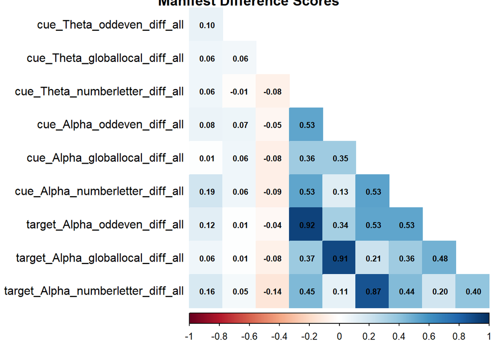

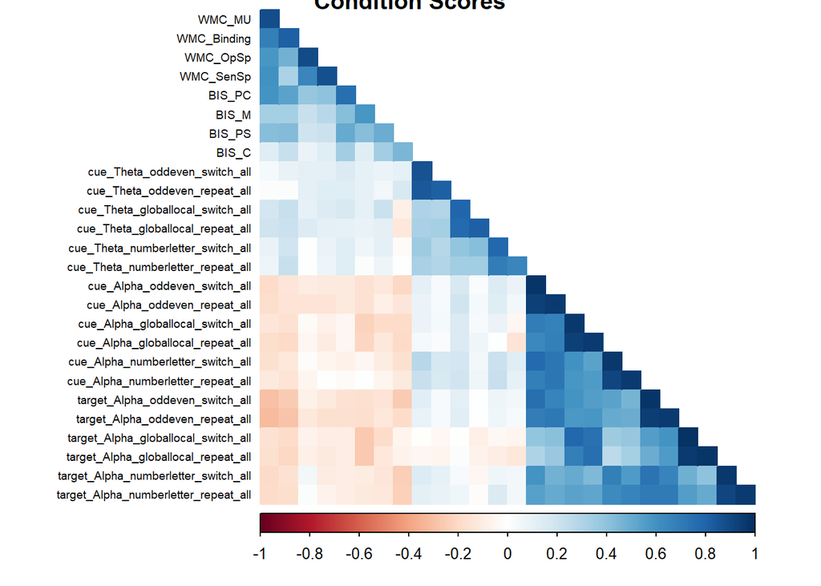

# MEASUREMENT MODELS FOR FLEXIBILITY

## Cue-related Theta

There are 53 missings in the data.

```
## lavaan 0.6-19 ended normally after 32 iterations
##
##   Estimator                                         ML
##   Optimization method                           NLMINB
##   Number of model parameters                        15
##
##                                                   Used       Total
##   Number of observations                           147         148
##   Number of missing patterns                         8
##
## Model Test User Model:
##
##   Test statistic                                19.162
##   Degrees of freedom                                12
##   P-value (Chi-square)                           0.085
##
## Model Test Baseline Model:
##
##   Test statistic                               454.245
##   Degrees of freedom                                15
##   P-value                                        0.000
##
## User Model versus Baseline Model:
##
##   Comparative Fit Index (CFI)                    0.984
##   Tucker-Lewis Index (TLI)                       0.980
##
##   Robust Comparative Fit Index (CFI)             0.983
##   Robust Tucker-Lewis Index (TLI)                0.978
##
## Loglikelihood and Information Criteria:
##
##   Loglikelihood user model (H0)               -964.261
##   Loglikelihood unrestricted model (H1)       -954.680
##
##   Akaike (AIC)                                1958.522
##   Bayesian (BIC)                              2003.379
##   Sample-size adjusted Bayesian (SABIC)       1955.911
##
## Root Mean Square Error of Approximation:
```

[output cut: 119 more lines]

```
##     gl                0.655    0.093    7.052    0.000    0.473    0.837
##     nl                0.571    0.092    6.179    0.000    0.390    0.752
##     lc                0.043    0.066    0.648    0.517   -0.086    0.172
##    Std.lv  Std.all
##     0.083    0.083
##     0.228    0.229
##     0.281    0.283
##     0.193    0.193
##     0.203    0.203
##     0.307    0.305
##     0.000    0.000
##     1.000    1.000
##     1.000    1.000
##     1.000    1.000
##     1.000    1.000
```

The latent change model with cue-related theta ERSP did converge.

Model fit was acceptable regarding CFI and acceptable regarding RMSEA, $\chi^2$(12) = 19.16, *p* = .085, CFI = .98, RMSEA = .06, 90% CI [.000, .115].

Flexibility cannot be captured by this model, as the latent change factor is not significant (*p* = .517).

The correlation between the latent flexibility factor and the latent repeat factor is not significant (r = .18, *p* = .670).

Parameter Estimates

| lhs | op | rhs | est | se | z | pvalue | ci.lower | ci.upper |
| --- | --- | --- | --- | --- | --- | --- | --- | --- |
| sw | =~ | oe_switch | 1.000 | 0.000 | NA | NA | 1.000 | 1.000 |
| sw | =~ | gl_switch | 0.353 | 0.093 | 3.782 | 0.000 | 0.170 | 0.535 |
| sw | =~ | nl_switch | 0.395 | 0.092 | 4.283 | 0.000 | 0.214 | 0.576 |
| rp | =~ | oe_repeat | 1.000 | 0.000 | NA | NA | 1.000 | 1.000 |
| rp | =~ | gl_repeat | 0.415 | 0.095 | 4.357 | 0.000 | 0.228 | 0.602 |
| rp | =~ | nl_repeat | 0.401 | 0.100 | 4.030 | 0.000 | 0.206 | 0.596 |
| gl | =~ | gl_switch | 1.000 | 0.000 | NA | NA | 1.000 | 1.000 |
| gl | =~ | gl_repeat | 1.000 | 0.000 | NA | NA | 1.000 | 1.000 |
| nl | =~ | nl_switch | 1.000 | 0.000 | NA | NA | 1.000 | 1.000 |
| nl | =~ | nl_repeat | 1.000 | 0.000 | NA | NA | 1.000 | 1.000 |
| sw | ~ | rp | 1.000 | 0.000 | NA | NA | 1.000 | 1.000 |
| lc | =~ | sw | 1.000 | 0.000 | NA | NA | 1.000 | 1.000 |
| rp | ~~ | lc | 0.034 | 0.079 | 0.427 | 0.670 | -0.121 | 0.189 |
| oe_switch | ~1 |  | 0.000 | 0.000 | NA | NA | 0.000 | 0.000 |
| oe_repeat | ~1 |  | 0.000 | 0.000 | NA | NA | 0.000 | 0.000 |
| gl_switch | ~1 |  | 0.000 | 0.000 | NA | NA | 0.000 | 0.000 |
| gl_repeat | ~1 |  | 0.000 | 0.000 | NA | NA | 0.000 | 0.000 |
| nl_switch | ~1 |  | 0.000 | 0.000 | NA | NA | 0.000 | 0.000 |
| nl_repeat | ~1 |  | 0.000 | 0.000 | NA | NA | 0.000 | 0.000 |
| gl | ~~ | lc | 0.000 | 0.000 | NA | NA | 0.000 | 0.000 |
| nl | ~~ | lc | 0.000 | 0.000 | NA | NA | 0.000 | 0.000 |
| rp | ~~ | gl | 0.000 | 0.000 | NA | NA | 0.000 | 0.000 |
| rp | ~~ | nl | 0.000 | 0.000 | NA | NA | 0.000 | 0.000 |
| gl | ~~ | nl | 0.000 | 0.000 | NA | NA | 0.000 | 0.000 |
| oe_switch | ~~ | oe_switch | 0.083 | 0.081 | 1.026 | 0.305 | -0.076 | 0.242 |
| gl_switch | ~~ | gl_switch | 0.228 | 0.056 | 4.105 | 0.000 | 0.119 | 0.337 |
| nl_switch | ~~ | nl_switch | 0.281 | 0.068 | 4.156 | 0.000 | 0.149 | 0.414 |
| oe_repeat | ~~ | oe_repeat | 0.193 | 0.072 | 2.682 | 0.007 | 0.052 | 0.333 |
| gl_repeat | ~~ | gl_repeat | 0.203 | 0.055 | 3.705 | 0.000 | 0.095 | 0.310 |
| nl_repeat | ~~ | nl_repeat | 0.307 | 0.069 | 4.448 | 0.000 | 0.172 | 0.442 |
| sw | ~~ | sw | 0.000 | 0.000 | NA | NA | 0.000 | 0.000 |
| rp | ~~ | rp | 0.803 | 0.135 | 5.963 | 0.000 | 0.539 | 1.067 |
| gl | ~~ | gl | 0.655 | 0.093 | 7.052 | 0.000 | 0.473 | 0.837 |
| nl | ~~ | nl | 0.571 | 0.092 | 6.179 | 0.000 | 0.390 | 0.752 |
| lc | ~~ | lc | 0.043 | 0.066 | 0.648 | 0.517 | -0.086 | 0.172 |
| sw | ~1 |  | 0.000 | 0.000 | NA | NA | 0.000 | 0.000 |
| rp | ~1 |  | 0.000 | 0.000 | NA | NA | 0.000 | 0.000 |
| gl | ~1 |  | 0.000 | 0.000 | NA | NA | 0.000 | 0.000 |
| nl | ~1 |  | 0.000 | 0.000 | NA | NA | 0.000 | 0.000 |
| lc | ~1 |  | 0.000 | 0.000 | NA | NA | 0.000 | 0.000 |

Standardized Solution

| lhs | op | rhs | est.std | se | z | pvalue | ci.lower | ci.upper |
| --- | --- | --- | --- | --- | --- | --- | --- | --- |
| sw | =~ | oe_switch | 0.957 | 0.043 | 22.433 | 0.000 | 0.874 | 1.041 |
| sw | =~ | gl_switch | 0.338 | 0.080 | 4.217 | 0.000 | 0.181 | 0.494 |
| sw | =~ | nl_switch | 0.379 | 0.080 | 4.748 | 0.000 | 0.222 | 0.535 |
| rp | =~ | oe_repeat | 0.898 | 0.041 | 21.701 | 0.000 | 0.817 | 0.979 |
| rp | =~ | gl_repeat | 0.373 | 0.078 | 4.765 | 0.000 | 0.219 | 0.526 |
| rp | =~ | nl_repeat | 0.358 | 0.081 | 4.437 | 0.000 | 0.200 | 0.516 |
| gl | =~ | gl_switch | 0.811 | 0.039 | 20.631 | 0.000 | 0.734 | 0.888 |
| gl | =~ | gl_repeat | 0.811 | 0.041 | 19.860 | 0.000 | 0.731 | 0.891 |
| nl | =~ | nl_switch | 0.758 | 0.047 | 16.072 | 0.000 | 0.665 | 0.850 |
| nl | =~ | nl_repeat | 0.753 | 0.046 | 16.518 | 0.000 | 0.664 | 0.842 |
| sw | ~ | rp | 0.938 | 0.086 | 10.852 | 0.000 | 0.768 | 1.107 |
| lc | =~ | sw | 0.216 | 0.162 | 1.336 | 0.181 | -0.101 | 0.533 |
| rp | ~~ | lc | 0.182 | 0.486 | 0.375 | 0.708 | -0.770 | 1.134 |
| oe_switch | ~1 |  | 0.000 | 0.000 | NA | NA | 0.000 | 0.000 |
| oe_repeat | ~1 |  | 0.000 | 0.000 | NA | NA | 0.000 | 0.000 |
| gl_switch | ~1 |  | 0.000 | 0.000 | NA | NA | 0.000 | 0.000 |
| gl_repeat | ~1 |  | 0.000 | 0.000 | NA | NA | 0.000 | 0.000 |
| nl_switch | ~1 |  | 0.000 | 0.000 | NA | NA | 0.000 | 0.000 |
| nl_repeat | ~1 |  | 0.000 | 0.000 | NA | NA | 0.000 | 0.000 |
| gl | ~~ | lc | 0.000 | 0.000 | NA | NA | 0.000 | 0.000 |
| nl | ~~ | lc | 0.000 | 0.000 | NA | NA | 0.000 | 0.000 |
| rp | ~~ | gl | 0.000 | 0.000 | NA | NA | 0.000 | 0.000 |
| rp | ~~ | nl | 0.000 | 0.000 | NA | NA | 0.000 | 0.000 |
| gl | ~~ | nl | 0.000 | 0.000 | NA | NA | 0.000 | 0.000 |
| oe_switch | ~~ | oe_switch | 0.083 | 0.082 | 1.019 | 0.308 | -0.077 | 0.243 |
| gl_switch | ~~ | gl_switch | 0.229 | 0.050 | 4.533 | 0.000 | 0.130 | 0.328 |
| nl_switch | ~~ | nl_switch | 0.283 | 0.061 | 4.597 | 0.000 | 0.162 | 0.403 |
| oe_repeat | ~~ | oe_repeat | 0.193 | 0.074 | 2.601 | 0.009 | 0.048 | 0.339 |
| gl_repeat | ~~ | gl_repeat | 0.203 | 0.051 | 3.986 | 0.000 | 0.103 | 0.304 |
| nl_repeat | ~~ | nl_repeat | 0.305 | 0.060 | 5.044 | 0.000 | 0.186 | 0.423 |
| sw | ~~ | sw | 0.000 | 0.000 | NA | NA | 0.000 | 0.000 |
| rp | ~~ | rp | 1.000 | 0.000 | NA | NA | 1.000 | 1.000 |
| gl | ~~ | gl | 1.000 | 0.000 | NA | NA | 1.000 | 1.000 |
| nl | ~~ | nl | 1.000 | 0.000 | NA | NA | 1.000 | 1.000 |
| lc | ~~ | lc | 1.000 | 0.000 | NA | NA | 1.000 | 1.000 |
| sw | ~1 |  | 0.000 | 0.000 | NA | NA | 0.000 | 0.000 |
| rp | ~1 |  | 0.000 | 0.000 | NA | NA | 0.000 | 0.000 |
| gl | ~1 |  | 0.000 | 0.000 | NA | NA | 0.000 | 0.000 |
| nl | ~1 |  | 0.000 | 0.000 | NA | NA | 0.000 | 0.000 |
| lc | ~1 |  | 0.000 | 0.000 | NA | NA | 0.000 | 0.000 |

## Cue-related Alpha

There are 57 missings in the data.

```
## lavaan 0.6-19 ended normally after 52 iterations
##
##   Estimator                                         ML
##   Optimization method                           NLMINB
##   Number of model parameters                        15
##
##                                                   Used       Total
##   Number of observations                           146         148
##   Number of missing patterns                         6
##
## Model Test User Model:
##
##   Test statistic                                13.309
##   Degrees of freedom                                12
##   P-value (Chi-square)                           0.347
##
## Model Test Baseline Model:
##
##   Test statistic                              1093.068
##   Degrees of freedom                                15
##   P-value                                        0.000
##
## User Model versus Baseline Model:
##
##   Comparative Fit Index (CFI)                    0.999
##   Tucker-Lewis Index (TLI)                       0.998
##
##   Robust Comparative Fit Index (CFI)             0.999
##   Robust Tucker-Lewis Index (TLI)                0.998
##
## Loglikelihood and Information Criteria:
##
##   Loglikelihood user model (H0)               -636.248
##   Loglikelihood unrestricted model (H1)       -629.593
##
##   Akaike (AIC)                                1302.495
##   Bayesian (BIC)                              1347.249
##   Sample-size adjusted Bayesian (SABIC)       1299.783
##
## Root Mean Square Error of Approximation:
```

[output cut: 119 more lines]

```
##     gl                0.473    0.061    7.713    0.000    0.353    0.594
##     nl                0.375    0.051    7.320    0.000    0.275    0.476
##     lc                0.091    0.018    5.167    0.000    0.057    0.126
##    Std.lv  Std.all
##     0.021    0.022
##     0.033    0.035
##     0.017    0.017
##     0.022    0.022
##     0.067    0.069
##     0.089    0.086
##     0.000    0.000
##     1.000    1.000
##     1.000    1.000
##     1.000    1.000
##     1.000    1.000
```

The latent change model with cue-related alpha ERSP did converge.

Model fit was good regarding CFI and good regarding RMSEA, $\chi^2$(12) = 13.31, *p* = .347, CFI = > .99, RMSEA = .03, 90% CI [.000, .091].

Flexibility can be captured by this model, as the latent change factor is significant (*p* < .001).

The correlation between the latent flexibility factor and the latent repeat factor is not significant (r = -.17, *p* = .175).

Parameter Estimates

| lhs | op | rhs | est | se | z | pvalue | ci.lower | ci.upper |
| --- | --- | --- | --- | --- | --- | --- | --- | --- |
| sw | =~ | oe_switch | 1.000 | 0.000 | NA | NA | 1.000 | 1.000 |
| sw | =~ | gl_switch | 0.672 | 0.062 | 10.906 | 0.000 | 0.552 | 0.793 |
| sw | =~ | nl_switch | 0.813 | 0.056 | 14.576 | 0.000 | 0.704 | 0.923 |
| rp | =~ | oe_repeat | 1.000 | 0.000 | NA | NA | 1.000 | 1.000 |
| rp | =~ | gl_repeat | 0.664 | 0.064 | 10.379 | 0.000 | 0.539 | 0.790 |
| rp | =~ | nl_repeat | 0.766 | 0.060 | 12.848 | 0.000 | 0.649 | 0.883 |
| gl | =~ | gl_switch | 1.000 | 0.000 | NA | NA | 1.000 | 1.000 |
| gl | =~ | gl_repeat | 1.000 | 0.000 | NA | NA | 1.000 | 1.000 |
| nl | =~ | nl_switch | 1.000 | 0.000 | NA | NA | 1.000 | 1.000 |
| nl | =~ | nl_repeat | 1.000 | 0.000 | NA | NA | 1.000 | 1.000 |
| sw | ~ | rp | 1.000 | 0.000 | NA | NA | 1.000 | 1.000 |
| lc | =~ | sw | 1.000 | 0.000 | NA | NA | 1.000 | 1.000 |
| rp | ~~ | lc | -0.050 | 0.037 | -1.357 | 0.175 | -0.123 | 0.022 |
| oe_switch | ~1 |  | 0.000 | 0.000 | NA | NA | 0.000 | 0.000 |
| oe_repeat | ~1 |  | 0.000 | 0.000 | NA | NA | 0.000 | 0.000 |
| gl_switch | ~1 |  | 0.000 | 0.000 | NA | NA | 0.000 | 0.000 |
| gl_repeat | ~1 |  | 0.000 | 0.000 | NA | NA | 0.000 | 0.000 |
| nl_switch | ~1 |  | 0.000 | 0.000 | NA | NA | 0.000 | 0.000 |
| nl_repeat | ~1 |  | 0.000 | 0.000 | NA | NA | 0.000 | 0.000 |
| gl | ~~ | lc | 0.000 | 0.000 | NA | NA | 0.000 | 0.000 |
| nl | ~~ | lc | 0.000 | 0.000 | NA | NA | 0.000 | 0.000 |
| rp | ~~ | gl | 0.000 | 0.000 | NA | NA | 0.000 | 0.000 |
| rp | ~~ | nl | 0.000 | 0.000 | NA | NA | 0.000 | 0.000 |
| gl | ~~ | nl | 0.000 | 0.000 | NA | NA | 0.000 | 0.000 |
| oe_switch | ~~ | oe_switch | 0.021 | 0.018 | 1.225 | 0.221 | -0.013 | 0.056 |
| gl_switch | ~~ | gl_switch | 0.033 | 0.022 | 1.489 | 0.136 | -0.010 | 0.076 |
| nl_switch | ~~ | nl_switch | 0.017 | 0.021 | 0.838 | 0.402 | -0.023 | 0.058 |
| oe_repeat | ~~ | oe_repeat | 0.022 | 0.020 | 1.112 | 0.266 | -0.017 | 0.062 |
| gl_repeat | ~~ | gl_repeat | 0.067 | 0.023 | 2.903 | 0.004 | 0.022 | 0.113 |
| nl_repeat | ~~ | nl_repeat | 0.089 | 0.024 | 3.784 | 0.000 | 0.043 | 0.135 |
| sw | ~~ | sw | 0.000 | 0.000 | NA | NA | 0.000 | 0.000 |
| rp | ~~ | rp | 0.982 | 0.121 | 8.107 | 0.000 | 0.745 | 1.220 |
| gl | ~~ | gl | 0.473 | 0.061 | 7.713 | 0.000 | 0.353 | 0.594 |
| nl | ~~ | nl | 0.375 | 0.051 | 7.320 | 0.000 | 0.275 | 0.476 |
| lc | ~~ | lc | 0.091 | 0.018 | 5.167 | 0.000 | 0.057 | 0.126 |
| sw | ~1 |  | 0.000 | 0.000 | NA | NA | 0.000 | 0.000 |
| rp | ~1 |  | 0.000 | 0.000 | NA | NA | 0.000 | 0.000 |
| gl | ~1 |  | 0.000 | 0.000 | NA | NA | 0.000 | 0.000 |
| nl | ~1 |  | 0.000 | 0.000 | NA | NA | 0.000 | 0.000 |
| lc | ~1 |  | 0.000 | 0.000 | NA | NA | 0.000 | 0.000 |

Standardized Solution

| lhs | op | rhs | est.std | se | z | pvalue | ci.lower | ci.upper |
| --- | --- | --- | --- | --- | --- | --- | --- | --- |
| sw | =~ | oe_switch | 0.989 | 0.009 | 109.880 | 0.000 | 0.972 | 1.007 |
| sw | =~ | gl_switch | 0.682 | 0.047 | 14.365 | 0.000 | 0.589 | 0.775 |
| sw | =~ | nl_switch | 0.788 | 0.033 | 23.899 | 0.000 | 0.723 | 0.853 |
| rp | =~ | oe_repeat | 0.989 | 0.010 | 96.800 | 0.000 | 0.969 | 1.009 |
| rp | =~ | gl_repeat | 0.667 | 0.050 | 13.409 | 0.000 | 0.569 | 0.764 |
| rp | =~ | nl_repeat | 0.744 | 0.038 | 19.524 | 0.000 | 0.670 | 0.819 |
| gl | =~ | gl_switch | 0.707 | 0.046 | 15.510 | 0.000 | 0.618 | 0.797 |
| gl | =~ | gl_repeat | 0.697 | 0.043 | 16.065 | 0.000 | 0.612 | 0.782 |
| nl | =~ | nl_switch | 0.602 | 0.043 | 14.118 | 0.000 | 0.518 | 0.685 |
| nl | =~ | nl_repeat | 0.600 | 0.041 | 14.742 | 0.000 | 0.521 | 0.680 |
| sw | ~ | rp | 1.005 | 0.036 | 27.841 | 0.000 | 0.934 | 1.076 |
| lc | =~ | sw | 0.306 | 0.035 | 8.869 | 0.000 | 0.238 | 0.374 |
| rp | ~~ | lc | -0.169 | 0.117 | -1.446 | 0.148 | -0.397 | 0.060 |
| oe_switch | ~1 |  | 0.000 | 0.000 | NA | NA | 0.000 | 0.000 |
| oe_repeat | ~1 |  | 0.000 | 0.000 | NA | NA | 0.000 | 0.000 |
| gl_switch | ~1 |  | 0.000 | 0.000 | NA | NA | 0.000 | 0.000 |
| gl_repeat | ~1 |  | 0.000 | 0.000 | NA | NA | 0.000 | 0.000 |
| nl_switch | ~1 |  | 0.000 | 0.000 | NA | NA | 0.000 | 0.000 |
| nl_repeat | ~1 |  | 0.000 | 0.000 | NA | NA | 0.000 | 0.000 |
| gl | ~~ | lc | 0.000 | 0.000 | NA | NA | 0.000 | 0.000 |
| nl | ~~ | lc | 0.000 | 0.000 | NA | NA | 0.000 | 0.000 |
| rp | ~~ | gl | 0.000 | 0.000 | NA | NA | 0.000 | 0.000 |
| rp | ~~ | nl | 0.000 | 0.000 | NA | NA | 0.000 | 0.000 |
| gl | ~~ | nl | 0.000 | 0.000 | NA | NA | 0.000 | 0.000 |
| oe_switch | ~~ | oe_switch | 0.022 | 0.018 | 1.212 | 0.225 | -0.013 | 0.056 |
| gl_switch | ~~ | gl_switch | 0.035 | 0.023 | 1.502 | 0.133 | -0.011 | 0.080 |
| nl_switch | ~~ | nl_switch | 0.017 | 0.020 | 0.835 | 0.403 | -0.023 | 0.056 |
| oe_repeat | ~~ | oe_repeat | 0.022 | 0.020 | 1.103 | 0.270 | -0.017 | 0.062 |
| gl_repeat | ~~ | gl_repeat | 0.069 | 0.024 | 2.928 | 0.003 | 0.023 | 0.116 |
| nl_repeat | ~~ | nl_repeat | 0.086 | 0.023 | 3.778 | 0.000 | 0.041 | 0.130 |
| sw | ~~ | sw | 0.000 | 0.000 | NA | NA | 0.000 | 0.000 |
| rp | ~~ | rp | 1.000 | 0.000 | NA | NA | 1.000 | 1.000 |
| gl | ~~ | gl | 1.000 | 0.000 | NA | NA | 1.000 | 1.000 |
| nl | ~~ | nl | 1.000 | 0.000 | NA | NA | 1.000 | 1.000 |
| lc | ~~ | lc | 1.000 | 0.000 | NA | NA | 1.000 | 1.000 |
| sw | ~1 |  | 0.000 | 0.000 | NA | NA | 0.000 | 0.000 |
| rp | ~1 |  | 0.000 | 0.000 | NA | NA | 0.000 | 0.000 |
| gl | ~1 |  | 0.000 | 0.000 | NA | NA | 0.000 | 0.000 |
| nl | ~1 |  | 0.000 | 0.000 | NA | NA | 0.000 | 0.000 |
| lc | ~1 |  | 0.000 | 0.000 | NA | NA | 0.000 | 0.000 |

## Target-related Alpha

There are 53 missings in the data.

```
## lavaan 0.6-19 ended normally after 52 iterations
##
##   Estimator                                         ML
##   Optimization method                           NLMINB
##   Number of model parameters                        15
##
##                                                   Used       Total
##   Number of observations                           147         148
##   Number of missing patterns                         6
##
## Model Test User Model:
##
##   Test statistic                                26.941
##   Degrees of freedom                                12
##   P-value (Chi-square)                           0.008
##
## Model Test Baseline Model:
##
##   Test statistic                              1128.329
##   Degrees of freedom                                15
##   P-value                                        0.000
##
## User Model versus Baseline Model:
##
##   Comparative Fit Index (CFI)                    0.987
##   Tucker-Lewis Index (TLI)                       0.983
##
##   Robust Comparative Fit Index (CFI)             0.986
##   Robust Tucker-Lewis Index (TLI)                0.983
##
## Loglikelihood and Information Criteria:
##
##   Loglikelihood user model (H0)               -631.109
##   Loglikelihood unrestricted model (H1)       -617.638
##
##   Akaike (AIC)                                1292.217
##   Bayesian (BIC)                              1337.074
##   Sample-size adjusted Bayesian (SABIC)       1289.606
##
## Root Mean Square Error of Approximation:
```

[output cut: 119 more lines]

```
##     gl                0.627    0.078    8.063    0.000    0.475    0.779
##     nl                0.395    0.055    7.183    0.000    0.288    0.503
##     lc                0.078    0.015    5.162    0.000    0.049    0.108
##    Std.lv  Std.all
##     0.005    0.005
##     0.044    0.045
##     0.038    0.037
##     0.023    0.022
##     0.032    0.035
##     0.083    0.075
##     0.000    0.000
##     1.000    1.000
##     1.000    1.000
##     1.000    1.000
##     1.000    1.000
```

The latent change model with target-related alpha ERSP did converge.

Flexibility can be captured by this model, as the latent change factor is significant (*p* < .001).

The correlation between the latent flexibility factor and the latent repeat factor is not significant (r = -.11, *p* = .390).

Parameter Estimates

| lhs | op | rhs | est | se | z | pvalue | ci.lower | ci.upper |
| --- | --- | --- | --- | --- | --- | --- | --- | --- |
| sw | =~ | oe_switch | 1.000 | 0.000 | NA | NA | 1.000 | 1.000 |
| sw | =~ | gl_switch | 0.546 | 0.065 | 8.439 | 0.000 | 0.419 | 0.673 |
| sw | =~ | nl_switch | 0.740 | 0.056 | 13.296 | 0.000 | 0.631 | 0.849 |
| rp | =~ | oe_repeat | 1.000 | 0.000 | NA | NA | 1.000 | 1.000 |
| rp | =~ | gl_repeat | 0.517 | 0.063 | 8.163 | 0.000 | 0.393 | 0.641 |
| rp | =~ | nl_repeat | 0.777 | 0.060 | 12.855 | 0.000 | 0.659 | 0.896 |
| gl | =~ | gl_switch | 1.000 | 0.000 | NA | NA | 1.000 | 1.000 |
| gl | =~ | gl_repeat | 1.000 | 0.000 | NA | NA | 1.000 | 1.000 |
| nl | =~ | nl_switch | 1.000 | 0.000 | NA | NA | 1.000 | 1.000 |
| nl | =~ | nl_repeat | 1.000 | 0.000 | NA | NA | 1.000 | 1.000 |
| sw | ~ | rp | 1.000 | 0.000 | NA | NA | 1.000 | 1.000 |
| lc | =~ | sw | 1.000 | 0.000 | NA | NA | 1.000 | 1.000 |
| rp | ~~ | lc | -0.031 | 0.036 | -0.860 | 0.390 | -0.101 | 0.039 |
| oe_switch | ~1 |  | 0.000 | 0.000 | NA | NA | 0.000 | 0.000 |
| oe_repeat | ~1 |  | 0.000 | 0.000 | NA | NA | 0.000 | 0.000 |
| gl_switch | ~1 |  | 0.000 | 0.000 | NA | NA | 0.000 | 0.000 |
| gl_repeat | ~1 |  | 0.000 | 0.000 | NA | NA | 0.000 | 0.000 |
| nl_switch | ~1 |  | 0.000 | 0.000 | NA | NA | 0.000 | 0.000 |
| nl_repeat | ~1 |  | 0.000 | 0.000 | NA | NA | 0.000 | 0.000 |
| gl | ~~ | lc | 0.000 | 0.000 | NA | NA | 0.000 | 0.000 |
| nl | ~~ | lc | 0.000 | 0.000 | NA | NA | 0.000 | 0.000 |
| rp | ~~ | gl | 0.000 | 0.000 | NA | NA | 0.000 | 0.000 |
| rp | ~~ | nl | 0.000 | 0.000 | NA | NA | 0.000 | 0.000 |
| gl | ~~ | nl | 0.000 | 0.000 | NA | NA | 0.000 | 0.000 |
| oe_switch | ~~ | oe_switch | 0.005 | 0.020 | 0.233 | 0.816 | -0.035 | 0.045 |
| gl_switch | ~~ | gl_switch | 0.044 | 0.021 | 2.083 | 0.037 | 0.003 | 0.086 |
| nl_switch | ~~ | nl_switch | 0.038 | 0.023 | 1.650 | 0.099 | -0.007 | 0.082 |
| oe_repeat | ~~ | oe_repeat | 0.023 | 0.020 | 1.135 | 0.256 | -0.017 | 0.063 |
| gl_repeat | ~~ | gl_repeat | 0.032 | 0.021 | 1.568 | 0.117 | -0.008 | 0.073 |
| nl_repeat | ~~ | nl_repeat | 0.083 | 0.026 | 3.242 | 0.001 | 0.033 | 0.133 |
| sw | ~~ | sw | 0.000 | 0.000 | NA | NA | 0.000 | 0.000 |
| rp | ~~ | rp | 1.038 | 0.131 | 7.940 | 0.000 | 0.782 | 1.294 |
| gl | ~~ | gl | 0.627 | 0.078 | 8.063 | 0.000 | 0.475 | 0.779 |
| nl | ~~ | nl | 0.395 | 0.055 | 7.183 | 0.000 | 0.288 | 0.503 |
| lc | ~~ | lc | 0.078 | 0.015 | 5.162 | 0.000 | 0.049 | 0.108 |
| sw | ~1 |  | 0.000 | 0.000 | NA | NA | 0.000 | 0.000 |
| rp | ~1 |  | 0.000 | 0.000 | NA | NA | 0.000 | 0.000 |
| gl | ~1 |  | 0.000 | 0.000 | NA | NA | 0.000 | 0.000 |
| nl | ~1 |  | 0.000 | 0.000 | NA | NA | 0.000 | 0.000 |
| lc | ~1 |  | 0.000 | 0.000 | NA | NA | 0.000 | 0.000 |

Standardized Solution

| lhs | op | rhs | est.std | se | z | pvalue | ci.lower | ci.upper |
| --- | --- | --- | --- | --- | --- | --- | --- | --- |
| sw | =~ | oe_switch | 0.998 | 0.010 | 102.898 | 0.000 | 0.979 | 1.017 |
| sw | =~ | gl_switch | 0.565 | 0.056 | 10.045 | 0.000 | 0.455 | 0.675 |
| sw | =~ | nl_switch | 0.756 | 0.037 | 20.266 | 0.000 | 0.683 | 0.829 |
| rp | =~ | oe_repeat | 0.989 | 0.010 | 100.657 | 0.000 | 0.970 | 1.008 |
| rp | =~ | gl_repeat | 0.544 | 0.059 | 9.291 | 0.000 | 0.429 | 0.659 |
| rp | =~ | nl_repeat | 0.753 | 0.038 | 19.810 | 0.000 | 0.679 | 0.828 |
| gl | =~ | gl_switch | 0.798 | 0.039 | 20.223 | 0.000 | 0.720 | 0.875 |
| gl | =~ | gl_repeat | 0.818 | 0.038 | 21.458 | 0.000 | 0.743 | 0.893 |
| nl | =~ | nl_switch | 0.625 | 0.044 | 14.230 | 0.000 | 0.539 | 0.712 |
| nl | =~ | nl_repeat | 0.598 | 0.042 | 14.304 | 0.000 | 0.516 | 0.680 |
| sw | ~ | rp | 0.992 | 0.033 | 29.697 | 0.000 | 0.927 | 1.058 |
| lc | =~ | sw | 0.272 | 0.030 | 8.980 | 0.000 | 0.213 | 0.332 |
| rp | ~~ | lc | -0.108 | 0.122 | -0.883 | 0.378 | -0.348 | 0.132 |
| oe_switch | ~1 |  | 0.000 | 0.000 | NA | NA | 0.000 | 0.000 |
| oe_repeat | ~1 |  | 0.000 | 0.000 | NA | NA | 0.000 | 0.000 |
| gl_switch | ~1 |  | 0.000 | 0.000 | NA | NA | 0.000 | 0.000 |
| gl_repeat | ~1 |  | 0.000 | 0.000 | NA | NA | 0.000 | 0.000 |
| nl_switch | ~1 |  | 0.000 | 0.000 | NA | NA | 0.000 | 0.000 |
| nl_repeat | ~1 |  | 0.000 | 0.000 | NA | NA | 0.000 | 0.000 |
| gl | ~~ | lc | 0.000 | 0.000 | NA | NA | 0.000 | 0.000 |
| nl | ~~ | lc | 0.000 | 0.000 | NA | NA | 0.000 | 0.000 |
| rp | ~~ | gl | 0.000 | 0.000 | NA | NA | 0.000 | 0.000 |
| rp | ~~ | nl | 0.000 | 0.000 | NA | NA | 0.000 | 0.000 |
| gl | ~~ | nl | 0.000 | 0.000 | NA | NA | 0.000 | 0.000 |
| oe_switch | ~~ | oe_switch | 0.005 | 0.019 | 0.233 | 0.816 | -0.033 | 0.042 |
| gl_switch | ~~ | gl_switch | 0.045 | 0.021 | 2.143 | 0.032 | 0.004 | 0.086 |
| nl_switch | ~~ | nl_switch | 0.037 | 0.023 | 1.637 | 0.102 | -0.007 | 0.082 |
| oe_repeat | ~~ | oe_repeat | 0.022 | 0.019 | 1.123 | 0.261 | -0.016 | 0.060 |
| gl_repeat | ~~ | gl_repeat | 0.035 | 0.022 | 1.567 | 0.117 | -0.009 | 0.078 |
| nl_repeat | ~~ | nl_repeat | 0.075 | 0.023 | 3.264 | 0.001 | 0.030 | 0.120 |
| sw | ~~ | sw | 0.000 | 0.000 | NA | NA | 0.000 | 0.000 |
| rp | ~~ | rp | 1.000 | 0.000 | NA | NA | 1.000 | 1.000 |
| gl | ~~ | gl | 1.000 | 0.000 | NA | NA | 1.000 | 1.000 |
| nl | ~~ | nl | 1.000 | 0.000 | NA | NA | 1.000 | 1.000 |
| lc | ~~ | lc | 1.000 | 0.000 | NA | NA | 1.000 | 1.000 |
| sw | ~1 |  | 0.000 | 0.000 | NA | NA | 0.000 | 0.000 |
| rp | ~1 |  | 0.000 | 0.000 | NA | NA | 0.000 | 0.000 |
| gl | ~1 |  | 0.000 | 0.000 | NA | NA | 0.000 | 0.000 |
| nl | ~1 |  | 0.000 | 0.000 | NA | NA | 0.000 | 0.000 |
| lc | ~1 |  | 0.000 | 0.000 | NA | NA | 0.000 | 0.000 |

## Overview

| ERSP cluster | converged | $\chi^2$ | df | *p* | CFI | RMSEA [90% CI] | p of flexibility factor |
| --- | --- | --- | --- | --- | --- | --- | --- |
| cue-related theta | yes | 19.16 | 12 | = .085 | .98 | .06 [.000, .115] | = .517 |
| cue-related alpha | yes | 13.31 | 12 | = .347 | > .99 | .03 [.000, .091] | < .001 |
| target-related alpha | yes | 26.94 | 12 | = .008 | .99 | .09 [.045, .139] | < .001 |

*Note.* The values here have simply been rounded. For the reported confidence intervals, the lower limit has been rounded down, while the upper limit has been rounded up.

# FLEXIBILITY, INTELLIGENCE, AND WMC

## Integrated alpha-based flexibility model

There are 192 missings in the data.

```
## lavaan 0.6-19 ended normally after 168 iterations
##
##   Estimator                                         ML
##   Optimization method                           NLMINB
##   Number of model parameters                        68
##
##                                                   Used       Total
##   Number of observations                           147         148
##   Number of missing patterns                        18
##
## Model Test User Model:
##
##   Test statistic                               232.143
##   Degrees of freedom                               162
##   P-value (Chi-square)                           0.000
##
## Model Test Baseline Model:
##
##   Test statistic                              3829.981
##   Degrees of freedom                               190
##   P-value                                        0.000
##
## User Model versus Baseline Model:
##
##   Comparative Fit Index (CFI)                    0.981
##   Tucker-Lewis Index (TLI)                       0.977
##
##   Robust Comparative Fit Index (CFI)             0.979
##   Robust Tucker-Lewis Index (TLI)                0.976
##
## Loglikelihood and Information Criteria:
##
##   Loglikelihood user model (H0)              -2118.667
##   Loglikelihood unrestricted model (H1)      -2002.595
##
##   Akaike (AIC)                                4373.333
##   Bayesian (BIC)                              4576.683
##   Sample-size adjusted Bayesian (SABIC)       4361.494
##
## Root Mean Square Error of Approximation:
```

[output cut: 389 more lines]

```
##     0.710    0.715
##     0.577    0.581
##     0.845    0.851
##     0.000    0.000
##     1.000    1.000
##     0.000    0.000
##     1.000    1.000
##     1.000    1.000
##     1.000    1.000
##     1.000    1.000
##     1.000    1.000
##     1.000    1.000
##     1.000    1.000
##     1.000    1.000
##     1.000    1.000
```

Model fit was acceptable regarding CFI and acceptable regarding RMSEA, $\chi^2$(162) = 232.14, *p* < .001, CFI = .98, RMSEA = .05, 90% CI [.038, .069].

Cue-related flexibility can be captured by this model, as the latent change factor is significant (*p* < .001).

Target-related flexibility can be captured by this model, as the latent change factor is significant (*p* < .001).

Parameter Estimates

| lhs | op | rhs | est | se | z | pvalue | ci.lower | ci.upper |
| --- | --- | --- | --- | --- | --- | --- | --- | --- |
| sw_cue | =~ | oe_cue_switch | 1.000 | 0.000 | NA | NA | 1.000 | 1.000 |
| sw_cue | =~ | gl_cue_switch | 0.660 | 0.047 | 14.094 | 0.000 | 0.568 | 0.751 |
| sw_cue | =~ | nl_cue_switch | 0.803 | 0.049 | 16.452 | 0.000 | 0.707 | 0.898 |
| rp_cue | =~ | oe_cue_repeat | 1.000 | 0.000 | NA | NA | 1.000 | 1.000 |
| rp_cue | =~ | gl_cue_repeat | 0.685 | 0.050 | 13.675 | 0.000 | 0.587 | 0.783 |
| rp_cue | =~ | nl_cue_repeat | 0.757 | 0.050 | 15.008 | 0.000 | 0.658 | 0.856 |
| sw_target | =~ | oe_target_switch | 1.000 | 0.000 | NA | NA | 1.000 | 1.000 |
| sw_target | =~ | gl_target_switch | 0.558 | 0.049 | 11.406 | 0.000 | 0.462 | 0.654 |
| sw_target | =~ | nl_target_switch | 0.745 | 0.048 | 15.387 | 0.000 | 0.650 | 0.840 |
| rp_target | =~ | oe_target_repeat | 1.000 | 0.000 | NA | NA | 1.000 | 1.000 |
| rp_target | =~ | gl_target_repeat | 0.514 | 0.047 | 10.834 | 0.000 | 0.421 | 0.607 |
| rp_target | =~ | nl_target_repeat | 0.753 | 0.051 | 14.879 | 0.000 | 0.654 | 0.852 |
| wmc | =~ | WMC_MU | 1.000 | 0.000 | NA | NA | 1.000 | 1.000 |
| wmc | =~ | WMC_Binding | 0.893 | 0.094 | 9.488 | 0.000 | 0.708 | 1.077 |
| wmc | =~ | WMC_OpSp | 0.744 | 0.094 | 7.870 | 0.000 | 0.558 | 0.929 |
| wmc | =~ | WMC_SenSp | 0.709 | 0.089 | 7.928 | 0.000 | 0.534 | 0.884 |
| g | =~ | BIS_PC | 1.000 | 0.000 | NA | NA | 1.000 | 1.000 |
| g | =~ | BIS_M | 0.643 | 0.113 | 5.715 | 0.000 | 0.423 | 0.864 |
| g | =~ | BIS_PS | 0.779 | 0.117 | 6.676 | 0.000 | 0.551 | 1.008 |
| g | =~ | BIS_C | 0.465 | 0.111 | 4.185 | 0.000 | 0.247 | 0.683 |
| gl_cue | =~ | gl_cue_switch | 1.000 | 0.000 | NA | NA | 1.000 | 1.000 |
| gl_cue | =~ | gl_cue_repeat | 1.000 | 0.000 | NA | NA | 1.000 | 1.000 |
| nl_cue | =~ | nl_cue_switch | 1.000 | 0.000 | NA | NA | 1.000 | 1.000 |
| nl_cue | =~ | nl_cue_repeat | 1.000 | 0.000 | NA | NA | 1.000 | 1.000 |
| gl_target | =~ | gl_target_switch | 1.000 | 0.000 | NA | NA | 1.000 | 1.000 |
| gl_target | =~ | gl_target_repeat | 1.000 | 0.000 | NA | NA | 1.000 | 1.000 |
| nl_target | =~ | nl_target_switch | 1.000 | 0.000 | NA | NA | 1.000 | 1.000 |
| nl_target | =~ | nl_target_repeat | 1.000 | 0.000 | NA | NA | 1.000 | 1.000 |
| sw_cue | ~ | rp_cue | 1.000 | 0.000 | NA | NA | 1.000 | 1.000 |
| lc_cue | =~ | sw_cue | 1.000 | 0.000 | NA | NA | 1.000 | 1.000 |

[output cut: 118 more lines]

Standardized Solution

| lhs | op | rhs | est.std | se | z | pvalue | ci.lower | ci.upper |
| --- | --- | --- | --- | --- | --- | --- | --- | --- |
| sw_cue | =~ | oe_cue_switch | 0.996 | 0.008 | 123.726 | 0.000 | 0.980 | 1.012 |
| sw_cue | =~ | gl_cue_switch | 0.690 | 0.041 | 16.798 | 0.000 | 0.609 | 0.770 |
| sw_cue | =~ | nl_cue_switch | 0.785 | 0.032 | 24.409 | 0.000 | 0.722 | 0.848 |
| rp_cue | =~ | oe_cue_repeat | 0.981 | 0.010 | 103.093 | 0.000 | 0.963 | 1.000 |
| rp_cue | =~ | gl_cue_repeat | 0.686 | 0.041 | 16.805 | 0.000 | 0.606 | 0.766 |
| rp_cue | =~ | nl_cue_repeat | 0.749 | 0.036 | 20.945 | 0.000 | 0.679 | 0.820 |
| sw_target | =~ | oe_target_switch | 0.995 | 0.007 | 134.024 | 0.000 | 0.981 | 1.010 |
| sw_target | =~ | gl_target_switch | 0.566 | 0.047 | 11.950 | 0.000 | 0.473 | 0.658 |
| sw_target | =~ | nl_target_switch | 0.760 | 0.035 | 21.589 | 0.000 | 0.691 | 0.829 |
| rp_target | =~ | oe_target_repeat | 0.990 | 0.008 | 124.558 | 0.000 | 0.975 | 1.006 |
| rp_target | =~ | gl_target_repeat | 0.543 | 0.049 | 10.988 | 0.000 | 0.446 | 0.640 |
| rp_target | =~ | nl_target_repeat | 0.744 | 0.038 | 19.772 | 0.000 | 0.670 | 0.818 |
| wmc | =~ | WMC_MU | 0.905 | 0.033 | 27.326 | 0.000 | 0.840 | 0.970 |
| wmc | =~ | WMC_Binding | 0.791 | 0.045 | 17.664 | 0.000 | 0.703 | 0.879 |
| wmc | =~ | WMC_OpSp | 0.662 | 0.057 | 11.583 | 0.000 | 0.550 | 0.774 |
| wmc | =~ | WMC_SenSp | 0.636 | 0.060 | 10.658 | 0.000 | 0.519 | 0.753 |
| g | =~ | BIS_PC | 0.830 | 0.048 | 17.275 | 0.000 | 0.736 | 0.924 |
| g | =~ | BIS_M | 0.534 | 0.071 | 7.524 | 0.000 | 0.395 | 0.673 |
| g | =~ | BIS_PS | 0.647 | 0.063 | 10.270 | 0.000 | 0.524 | 0.771 |
| g | =~ | BIS_C | 0.386 | 0.082 | 4.714 | 0.000 | 0.226 | 0.547 |
| gl_cue | =~ | gl_cue_switch | 0.697 | 0.039 | 17.661 | 0.000 | 0.620 | 0.775 |
| gl_cue | =~ | gl_cue_repeat | 0.679 | 0.039 | 17.441 | 0.000 | 0.603 | 0.755 |
| nl_cue | =~ | nl_cue_switch | 0.590 | 0.041 | 14.506 | 0.000 | 0.510 | 0.669 |
| nl_cue | =~ | nl_cue_repeat | 0.607 | 0.040 | 15.045 | 0.000 | 0.528 | 0.686 |
| gl_target | =~ | gl_target_switch | 0.794 | 0.033 | 23.867 | 0.000 | 0.729 | 0.859 |
| gl_target | =~ | gl_target_repeat | 0.825 | 0.033 | 24.864 | 0.000 | 0.760 | 0.890 |
| nl_target | =~ | nl_target_switch | 0.623 | 0.043 | 14.342 | 0.000 | 0.538 | 0.708 |
| nl_target | =~ | nl_target_repeat | 0.601 | 0.040 | 15.037 | 0.000 | 0.523 | 0.680 |
| sw_cue | ~ | rp_cue | 0.983 | 0.032 | 30.342 | 0.000 | 0.920 | 1.047 |
| lc_cue | =~ | sw_cue | 0.285 | 0.032 | 8.852 | 0.000 | 0.222 | 0.348 |

[output cut: 118 more lines]

## Correlations

|  |  | 2. lc_target | 3. rp_cue | 4. rp_target | 5. BIS | 6. WMC |  |
| --- | --- | --- | --- | --- | --- | --- | --- |
| 1. | lc_cue | .98 [< .001] | -.09 [= .479] | -.01 [= .925] | -.11 [= .327] | .05 [= .630] |  |
| 2. | lc_target |  | -.09 [= .431] | -.15 [= .193] | -.02 [= .849] | .16 [= .152] |  |
| 3. | rp_cue |  |  | .73 [< .001] | -.17 [= .088] | -.23 [= .016] |  |
| 4. | rp_target |  |  |  | -.23 [= .020] | -.36 [< .001] |  |
| 5. | BIS |  |  |  |  | .78 [< .001] |  |